# CMSC 320 A Tutorial

## Data collection/curation + parsing

We go to the GitHub provided in rubric and download the dataset Titanic.csv. This excel has many columns, including PassengerId, name, age and other information. PassengerId, Name: This information has no effect on survival from common sense. (I know there may have some royal name and some title may show something. But, I assume noble status will be reflected in the cabin now) Ticket: It looks messy and should not be used in data mining Cabin: Too many Null value in it. Drop this column. Pclass, Fare: Fare is closely related to Pclass. We only use Pclass to show where the customer is. Sex: Lady first. Important column. Age: Obviously Important. Parch, SibSp, Embarked: hard to say. It may be analyzed from the Family size and boarding city.

First of all, we need to read the csv file.

```python
import numpy as np
import pandas as pd
import matplotlib.pyplot as plt
import seaborn as sns
titanic = pd.read_csv(r'titanic.csv')
```

View statistics of passengers

```python
titanic.head()
titanic.describe()
```

|  | PassengerId | Survived | Pclass | Age | SibSp | Parch | Fare |
| --- | --- | --- | --- | --- | --- | --- | --- |
| count | 891.000000 | 891.000000 | 891.000000 | 714.000000 | 891.000000 | 891.000000 | 891.000000 |
| mean | 446.000000 | 0.383838 | 2.308642 | 29.699118 | 0.523008 | 0.381594 | 32.204208 |
| std | 257.353842 | 0.486592 | 0.836071 | 14.526497 | 1.102743 | 0.806057 | 49.693429 |
| min | 1.000000 | 0.000000 | 1.000000 | 0.420000 | 0.000000 | 0.000000 | 0.000000 |
| 25% | 223.500000 | 0.000000 | 2.000000 | 20.125000 | 0.000000 | 0.000000 | 7.910400 |
| 50% | 446.000000 | 0.000000 | 3.000000 | 28.000000 | 0.000000 | 0.000000 | 14.454200 |
| 75% | 668.500000 | 1.000000 | 3.000000 | 38.000000 | 1.000000 | 0.000000 | 31.000000 |
| max | 891.000000 | 1.000000 | 3.000000 | 80.000000 | 8.000000 | 6.000000 | 512.329200 |

Check the null val

```python
titanic.info()
```

```
<class 'pandas.core.frame.DataFrame'>
RangeIndex: 891 entries, 0 to 890
Data columns (total 12 columns):
 #   Column       Non-Null Count  Dtype
---  ------       --------------  -----
 0   PassengerId  891 non-null    int64
 1   Survived     891 non-null    int64
 2   Pclass       891 non-null    int64
 3   Name         891 non-null    object
 4   Sex          891 non-null    object
 5   Age          714 non-null    float64
 6   SibSp        891 non-null    int64
 7   Parch        891 non-null    int64
 8   Ticket       891 non-null    object
 9   Fare         891 non-null    float64
 10  Cabin        204 non-null    object
 11  Embarked     889 non-null    object
dtypes: float64(2), int64(5), object(5)
memory usage: 83.7+ KB
```

We can see there are (891-714),(891-204),(891-889) null value in Age,Cabin,Embarked.

For Age, we use AVERAGE to fill the blank. For Embarked, we use MODE to fill the blank. For Cabin,we will drop this colume soon.

```python
titanic['Age'] =titanic['Age'].fillna(titanic['Age'].mean())
titanic['Embarked'].value_counts()
titanic['Embarked'] =titanic['Embarked'].fillna('S')# 646:168:77
```

Sex is string type now, convert into 1/0

```python
isMale = {'male':1,'female':0}
titanic['Sex'] = titanic['Sex'].map(isMale)
```

## Exploratory data analysis

First, we cross analyzed Pclass and survival. We suspect that different classes may affect the survival rate. We count the number of survivors and deaths in each Pclass. The bar graph is drawn by pyplot:

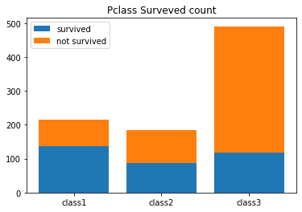

```python
class_survived=titanic[['Pclass','Survived']]
y_live=class_survived[class_survived.Survived==1].groupby('Pclass')['Survived'].count()
y_dead=class_survived[class_survived.Survived==0].groupby('Pclass')['Survived'].count()
pos=range(1,4)
defination=['class%d'%(i) for i in range(1,4)]
plt.bar(pos,y_live,label='survived')
plt.bar(pos,y_dead,bottom=y_live,label='not survived')
plt.legend()
plt.xticks(pos,defination)
plt.title('Pclass Surveved count')
plt.show()
```

We can clearly see that the survival rate of first class is higher than that of second class, and second class is much higher than that of third class. Our inference was confirmed by statistics.

Next, we suspect the survival rate may be related to gender. We count the number of survivors and deaths in male and female:We cross analyzed gender and survival

[figure not shown]

```python
sex_survived=titanic[['Sex','Survived']]
y_male=[0,0] #live/die
y_female=[0,0]#live/die
for i in range(len(sex_survived.Sex)):
    if sex_survived.Sex[i]:#male = 1, famale = 0
        if sex_survived.Survived[i]==0:
            y_male[0]+=1
        else:
            y_male[1]+=1
    else:
        if sex_survived.Survived[i]==0:
            y_female[0]+=1
        else:
            y_female[1]+=1
x_number=range(1,3)
x_word=['survived','not survived']
plt.bar(x_number,y_male,label='female')
plt.bar(x_number,y_female,bottom=y_male,label='male')
plt.legend()
plt.xticks(x_number,x_word)
plt.show()
```

We still want to explore which data are still relevant. We use sns.heatmap draws the heatmap of correlation.

```
          Survived    Pclass       Age     SibSp     Parch      Fare       Sex
Survived  1.000000 -0.338481 -0.069809 -0.035322  0.081629  0.257307 -0.543351
Pclass   -0.338481  1.000000 -0.331339  0.083081  0.018443 -0.549500  0.131900
Age      -0.069809 -0.331339  1.000000 -0.232625 -0.179191  0.091566  0.084153
SibSp    -0.035322  0.083081 -0.232625  1.000000  0.414838  0.159651 -0.114631
Parch     0.081629  0.018443 -0.179191  0.414838  1.000000  0.216225 -0.245489
Fare      0.257307 -0.549500  0.091566  0.159651  0.216225  1.000000 -0.182333
Sex      -0.543351  0.131900  0.084153 -0.114631 -0.245489 -0.182333  1.000000
```

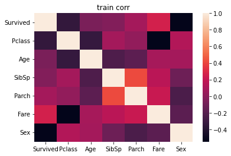

```python
data=titanic[['Survived','Pclass','Age','SibSp','Parch','Fare','Sex']]
data=data.corr()
print(data)
sns.heatmap(data)
plt.title('train corr')
plt.show()
```

As a continuous variable, fare can also be used for analysis. We ignore the future warning.

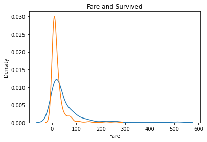

```python
import warnings
warnings.filterwarnings('ignore')
fare_survived=titanic[['Fare','Survived']]
sns.distplot(fare_survived[fare_survived.Survived==1].Fare,hist=False,label='Survived')
sns.distplot(fare_survived[fare_survived.Survived==0].Fare,hist=False,label='Dead')
plt.title('Fare and Survived')
plt.show()
```

We can find that the people who pay more has more chances to live

## Communication of insights attained(Exploratory work)

Back to Name, after communicating with others, I realized that names still symbolize some status. For example, Mr and Mrs in titles include gender and marital status. Major and Dr symbolize some social status.

```python
titanic['Name'].head
```

```
<bound method NDFrame.head of 0                                Braund, Mr. Owen Harris
1      Cumings, Mrs. John Bradley (Florence Briggs Th...
2                                 Heikkinen, Miss. Laina
3           Futrelle, Mrs. Jacques Heath (Lily May Peel)
4                               Allen, Mr. William Henry
                             ...
886                                Montvila, Rev. Juozas
887                         Graham, Miss. Margaret Edith
888             Johnston, Miss. Catherine Helen "Carrie"
889                                Behr, Mr. Karl Howell
890                                  Dooley, Mr. Patrick
Name: Name, Length: 891, dtype: object>
```

Split the name, get the Title in the name.

```python
def splitTitle(name):
    temp = name.split(',')[1].split('.')[0]
    temp1 = ''.join(temp)
    return temp1

titleDF=pd.DataFrame()
titleDF['Title']=titanic['Name'].map(splitTitle)
```

Show the counts of Each Title

```python
titleDF['Title'].value_counts()
```

```
 Mr              517
 Miss            182
 Mrs             125
 Master           40
 Dr                7
 Rev               6
 Mlle              2
 Major             2
 Col               2
 the Countess      1
 Capt              1
 Ms                1
 Sir               1
 Lady              1
 Mme               1
 Don               1
 Jonkheer          1
Name: Title, dtype: int64
```

We can see that there are too many titles. We need to simplify them and classify them into several categories. Through discussion, we divided all titles into six categories:

(1) Officer: government personnel (soldier + priest). (2) Royalty: royal family. (3) MR: adult man. (4) MRS: married woman. (5) Miss: young unmarried woman. (6) Master: mechanic, teacher

```python
titleMap = {
    'Mr':       'Mr',
    'Miss':     'Miss',
    'Mrs':      'Mrs',
    'Master':   'Master',
    'Dr':       'Officer',
    'Rev':      'Officer',
    'Mlle':     'Miss',
    'Major':    'Officer',
    'Col':      'Officer',
    'the Countess':'Royal',
    'Capt':     'Officer',
    'Ms':       'Mrs',
    'Sir':      'Mr',
    'Lady':     'Royal',
    'Mme':      'Mrs',
    'Don':      'Royal',
    'Jonkheer': 'Royal'
}
```

```python
# titleDF['Title']=titleDF['Title'].map(titleMap)
```

```python
titanic = pd.concat([titanic,titleDF],axis=1)
titanic.head()
```

|  | PassengerId | Survived | Pclass | Name | Sex | Age | SibSp | Parch | Ticket | Fare | Cabin | Embarked | Title |
| --- | --- | --- | --- | --- | --- | --- | --- | --- | --- | --- | --- | --- | --- |
| 0 | 1 | 0 | 3 | Braund, Mr. Owen Harris | 1 | 22.0 | 1 | 0 | A/5 21171 | 7.2500 | NaN | S | Mr |
| 1 | 2 | 1 | 1 | Cumings, Mrs. John Bradley (Florence Briggs Th... | 0 | 38.0 | 1 | 0 | PC 17599 | 71.2833 | C85 | C | Mrs |
| 2 | 3 | 1 | 3 | Heikkinen, Miss. Laina | 0 | 26.0 | 0 | 0 | STON/O2. 3101282 | 7.9250 | NaN | S | Miss |
| 3 | 4 | 1 | 1 | Futrelle, Mrs. Jacques Heath (Lily May Peel) | 0 | 35.0 | 1 | 0 | 113803 | 53.1000 | C123 | S | Mrs |
| 4 | 5 | 0 | 3 | Allen, Mr. William Henry | 1 | 35.0 | 0 | 0 | 373450 | 8.0500 | NaN | S | Mr |

```python
titleDF = pd.pivot_table(titanic,index='Title',columns = 'Survived',values = 'PassengerId',aggfunc = 'count')
```

```python
titleDF
```

| Survived Title | 0 | 1 |
| --- | --- | --- |
| Capt | 1.0 | NaN |
| Col | 1.0 | 1.0 |
| Don | 1.0 | NaN |
| Dr | 4.0 | 3.0 |
| Jonkheer | 1.0 | NaN |
| Lady | NaN | 1.0 |
| Major | 1.0 | 1.0 |
| Master | 17.0 | 23.0 |
| Miss | 55.0 | 127.0 |
| Mlle | NaN | 2.0 |
| Mme | NaN | 1.0 |
| Mr | 436.0 | 81.0 |
| Mrs | 26.0 | 99.0 |
| Ms | NaN | 1.0 |
| Rev | 6.0 | NaN |
| Sir | NaN | 1.0 |
| the Countess | NaN | 1.0 |

Get the SurviveRate

```python
titleDFtemp = titleDF.div(titleDF.sum(axis = 1),axis=0)
titleSurviveRate = titleDFtemp.iloc[:,1]
titleSurviveRate
```

```
Title
 Capt                 NaN
 Col             0.500000
 Don                  NaN
 Dr              0.428571
 Jonkheer             NaN
 Lady            1.000000
 Major           0.500000
 Master          0.575000
 Miss            0.697802
 Mlle            1.000000
 Mme             1.000000
 Mr              0.156673
 Mrs             0.792000
 Ms              1.000000
 Rev                  NaN
 Sir             1.000000
 the Countess    1.000000
Name: 1, dtype: float64
```

Since we are still trying different groups, we will hardcode a good distribution(six Simplified Title) here and draw the plt.

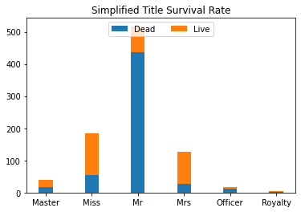

```python
fig = plt.figure()
x = np.array(["Master", "Miss", "Mr", "Mrs","Officer","Royalty"])
y1 = np.array([17,55,436,26,13,2])
y2 = np.array([23,129,81,101,5,3])
plt.bar(x, y1, width=0.3, label="Dead")
plt.bar(x, y2, width=0.3, label="Live",bottom=y1)
plt.title("Simplified Title Survival Rate", loc="center")
plt.grid(False)
plt.legend(loc="upper center", ncol=2)
plt.show()
```